# Stem Cell Network - scATAC-seq workshop

# Load dependencies

```r
library(Seurat) #CRAN
library(Signac) #CRAN
library(EnsDb.Hsapiens.v75) #Bioconductor
library(BSgenome.Hsapiens.UCSC.hg19) #Bioconductor
library(tidyverse) #CRAN
```

```
✖ lubridate::%within%() masks IRanges::%within%()
✖ lubridate::second<-() masks S4Vectors::second<-()
```

```r
library(chromVAR) #Bioconductor
```

```r
library(JASPAR2022) #Bioconductor
library(TFBSTools) #Bioconductor
library(ggseqlogo) #CRAN

#Installing CRAN packages: install.packages('ggseqlogo')
#Installing Bioconductor packages: BiocManager::install('biovizBase')
```

# Load data

Similar to scRNA-seq data, we are going to load ATAC-seq data into a Seurat object. Here, we will get more familiar with the idea of “assays” within the object.

## Download if you haven’t

If you have not downloaded the data for the workshop, you can download it into the project folder with the following (make sure this notebook is saved in the `notebooks/` subdirectory:

```r
# Peak-by-cell counts matrix
download.file(url = "https://cf.10xgenomics.com/samples/cell-atac/1.0.1/atac_v1_pbmc_10k/atac_v1_pbmc_10k_filtered_peak_bc_matrix.h5",
              destfile = "../data/atac_v1_pbmc_10k_filtered_peak_bc_matrix.h5")
# Cell metadata from cellranger
download.file(url = "https://cf.10xgenomics.com/samples/cell-atac/1.0.1/atac_v1_pbmc_10k/atac_v1_pbmc_10k_singlecell.csv",
              destfile = "atac_v1_pbmc_10k_singlecell.csv")
# File providing coordinates and ranges of each ATAC fragment in the library
download.file(url = "https://cf.10xgenomics.com/samples/cell-atac/1.0.1/atac_v1_pbmc_10k/atac_v1_pbmc_10k_fragments.tsv.gz",
              destfile = "../data/atac_v1_pbmc_10k_fragments.tsv.gz")
# Index file for the fragments
download.file(url = "https://cf.10xgenomics.com/samples/cell-atac/1.0.1/atac_v1_pbmc_10k/atac_v1_pbmc_10k_fragments.tsv.gz.tbi",
              destfile = "../data/atac_v1_pbmc_10k_fragments.tsv.gz.tbi")
# scRNA-seq of PBMCs in case you want to try integrating/comparing
download.file(url = "https://cf.10xgenomics.com/samples/cell/pbmc3k/pbmc3k_filtered_gene_bc_matrices.tar.gz",
              destfile = "../data/pbmc3k_filtered_gene_bc_matrices.tar.gz")
```

## Load files

```r
counts <- Read10X_h5("../data/atac_v1_pbmc_10k_filtered_peak_bc_matrix.h5")

metadata <- read.csv("../data/atac_v1_pbmc_10k_singlecell.csv",
                     header = TRUE, row.names = 1)
```

The `counts` variable is a region-by-cell count matrix. Each row represents a called peak.

```r
counts[1:3,1:3]
```

```
3 x 3 sparse Matrix of class "dgCMatrix"
                   AAACGAAAGAGCGAAA-1 AAACGAAAGAGTTTGA-1 AAACGAAAGCGAGCTA-1
chr1:565107-565550                  .                  .                  .
chr1:569174-569639                  .                  .                  .
chr1:713460-714823                  .                  .                  2
```

The `metadata` variable is returned by cellranger and provides QC information about each cell in the `counts` matrix.

```r
colnames(metadata)
```

```
 [1] "total"                            "duplicate"
 [3] "chimeric"                         "unmapped"
 [5] "lowmapq"                          "mitochondrial"
 [7] "passed_filters"                   "cell_id"
 [9] "is__cell_barcode"                 "TSS_fragments"
[11] "DNase_sensitive_region_fragments" "enhancer_region_fragments"
[13] "promoter_region_fragments"        "on_target_fragments"
[15] "blacklist_region_fragments"       "peak_region_fragments"
```

We next move the `counts` matrix into an “assay” that will be held within the seurat object. Similar to an RNA assay in a seurat object, a ChromatinAssay can contain both raw and normalized counts. It can also contain information about each of the peaks in the matrix, including motif presence, closest gene, etc

```r
chrom_assay <- CreateChromatinAssay(
  counts = counts,
  sep = c(":", "-"),
  fragments = '../data/atac_v1_pbmc_10k_fragments.tsv.gz',
  min.cells = 10,
  min.features = 200
)
```

```
Computing hash
Checking for 8728 cell barcodes
```

Store the assay and cell metadata in a Seurat object

```r
seurat_obj <- CreateSeuratObject(
  counts = chrom_assay,
  assay = "peaks",
  meta.data = metadata
)
```

Currently, the seurat object has genomic coordinates for peaks, but it doesn’t know which build of the genome these coordinates correspond to.

```r
# extract gene annotations from EnsDb
annotations <- GetGRangesFromEnsDb(ensdb = EnsDb.Hsapiens.v75)
```

[output not shown]

```r
# These annotations are based on the Ensembl build, but this data was mapped to
# a build with a slightly different format that encodes chromosomes as "chr1" vs. "1")
# We'll just add "chr" to the chromosome value for the annotations
seqlevels(annotations) <- paste0('chr', seqlevels(annotations))
genome(annotations) <- "hg19"

# Add this annotation to the seurat object
Annotation(seurat_obj) <- annotations
```

Now our seurat object has information about what specific genome was used for the alignment. This will be beneficial for any analysis that involves the positioning of genes relative to those coordinates.

```r
seurat_obj
```

```
An object of class Seurat
87561 features across 8728 samples within 1 assay
Active assay: peaks (87561 features, 0 variable features)
 2 layers present: counts, data
```

# Quality control

There are a handful of QC metrics we can evaluate: - total number of fragments in peaks: a measure of cell complexity - percentage of fragments that map to peaks vs. background regions (pct_reads_in_peaks) - nucleosome signal: ratio of nucleosome fragments (147-294bp) to nucleosome-free fragments - TSS enrichment: the extent to which fragments are more prevalent at the transcription start site of genes relative to flanking regions several kb away

```r
# compute nucleosome signal score per cell
seurat_obj <- NucleosomeSignal(seurat_obj)
```

[output not shown]

```r
# compute TSS enrichment score per cell
seurat_obj <- TSSEnrichment(seurat_obj, fast = FALSE)
```

```
Extracting TSS positions
Finding + strand cut sites
Finding - strand cut sites
Computing mean insertion frequency in flanking regions
Normalizing TSS score
```

```r
# add blacklist ratio and fraction of reads in peaks
seurat_obj$pct_reads_in_peaks <- seurat_obj$peak_region_fragments / seurat_obj$passed_filters * 100
seurat_obj$blacklist_ratio <- seurat_obj$blacklist_region_fragments / seurat_obj$peak_region_fragments
```

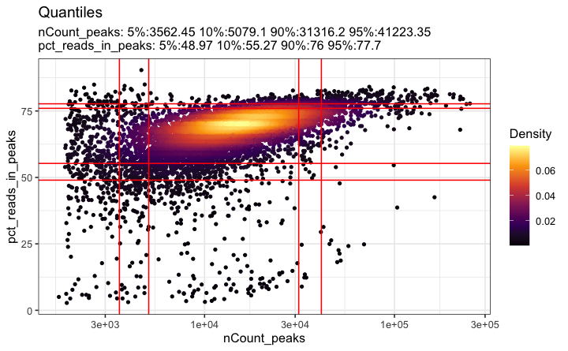

```r
DensityScatter(seurat_obj, x = 'nCount_peaks', y = 'pct_reads_in_peaks',
               log_x = T, quantiles = TRUE)
```

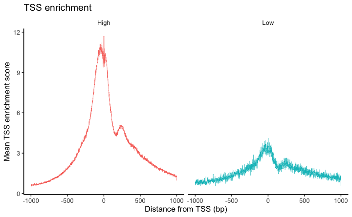

```r
seurat_obj$high.tss <- ifelse(seurat_obj$TSS.enrichment > 3, 'High', 'Low')
TSSPlot(seurat_obj, group.by = 'high.tss') + NoLegend()
```

And we can do a histogram of any of the QC metrics

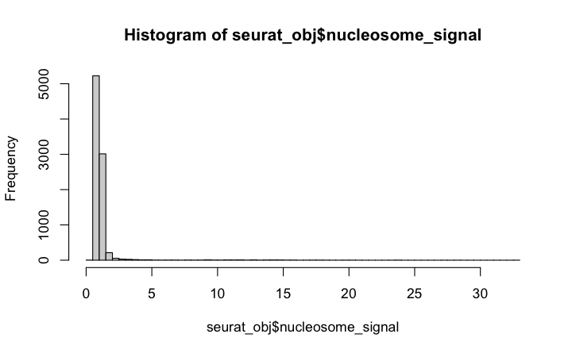

```r
hist(seurat_obj$nucleosome_signal, breaks=100)
```

```r
seurat_obj <- subset(
  seurat_obj,
  subset = nCount_peaks > 3000 &
    nCount_peaks < 50000 &
    pct_reads_in_peaks > 30 &
    blacklist_ratio < 0.05 &
    nucleosome_signal < 4 &
    TSS.enrichment > 3
)
seurat_obj
```

```
An object of class Seurat
87561 features across 7955 samples within 1 assay
Active assay: peaks (87561 features, 0 variable features)
 2 layers present: counts, data
```

# Preprocessing

## Normalization and dimensionality reduction

The nature of counts in an ATAC peak-by-cell matrix is very different from scRNA-seq: - Each cell only has a limited number of copies of a genomic region that can be cut (2 for a diploid cell), so the range of values is much less complex. - The number of features is often vastly larger than gene expression too (ie. up to 300k peaks vs. 20k transcripts).

Here, we perform two steps to normalize and embed the data. Together these steps are referred to as “Latent semantic indexing (LSI)”: 1) Normalization (TF-IDF; term frequency-inverse document frequency) - Term frequency = Weight all sites for a cell by the total number of sites for that cell - Inverse document frequency = Inverse frequency of the site across all cells

log(TF * IDF)

The IDF component will upweight peaks that aren’t super frequent across all cells, but are present in a cell of interest

2. SVD (singular value decomposition) - a matrix factorization approach (similar to PCA)

```r
seurat_obj <- RunTFIDF(seurat_obj)
```

```
Performing TF-IDF normalization
```

```r
seurat_obj <- FindTopFeatures(seurat_obj, min.cutoff = 'q10') #only run top 90% most common peaks
seurat_obj <- RunSVD(seurat_obj)
```

```
Running SVD
Scaling cell embeddings
```

Similar to PCA, the resulting components from SVD can capture technical features. With scATAC data, it is very common for the first component to simply reflect differences in peak count (or sequencing depth)

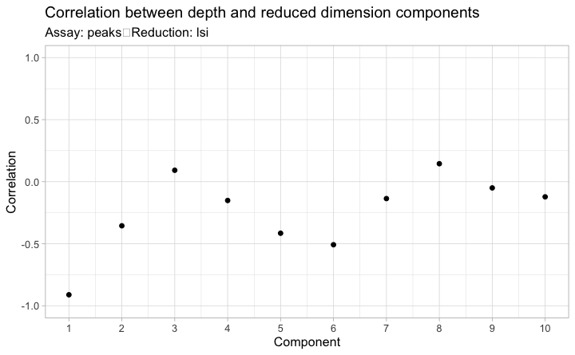

```r
DepthCor(seurat_obj)
```

So we can remove component 1 from downstream analysis

# Non-linear dimensionality reduction and clustering

Identical methods to scRNA-seq analysis. We’ll use UMAP to produce a two dimensional embedding, and will use graph-based clustering approaches to cluster the SVD embedding.

```r
#Note that we omit the 1st component when we set 2:30. We also specify the LSI reduction (embedding)
seurat_obj <- RunUMAP(seurat_obj, reduction = 'lsi', dims = 2:30)
seurat_obj <- FindNeighbors(seurat_obj, reduction = 'lsi', dims = 2:30)
seurat_obj <- FindClusters(seurat_obj, resolution=0.2)
```

```
Modularity Optimizer version 1.3.0 by Ludo Waltman and Nees Jan van Eck

Number of nodes: 7955
Number of edges: 282968

Running Louvain algorithm...
```

```
Maximum modularity in 10 random starts: 0.9419
Number of communities: 11
Elapsed time: 0 seconds
```

```
1 singletons identified. 10 final clusters.
```

We can now visualize a UMAP embedding of our data

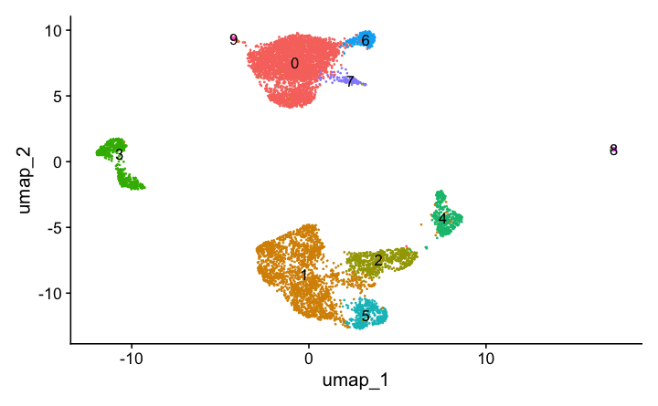

```r
DimPlot(seurat_obj, label = TRUE) + NoLegend()
```

Looks great–we can clearly see that there are several distinct populations

But what do they correspond to? We can’t simply look at gene expression to associate clusters with sepcific expression patterns

# Data exploration

We can use features of the ATAC profile to infer expression patterns based on the assumption that expressed genes have increased accessibility at regulatory elements.

First, we’ll look at a common ATAC-seq trace, creating `pseudobulk` profiles for each cluster (ie. summing up the peak counts for all cells)

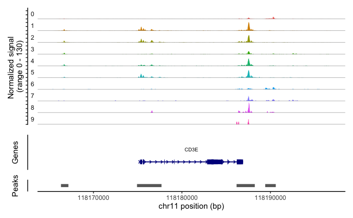

```r
CoveragePlot(seurat_obj,
             group.by="seurat_clusters",
             region = "CD3E",
             extend.upstream = 10000, extend.downstream = 10000)
```

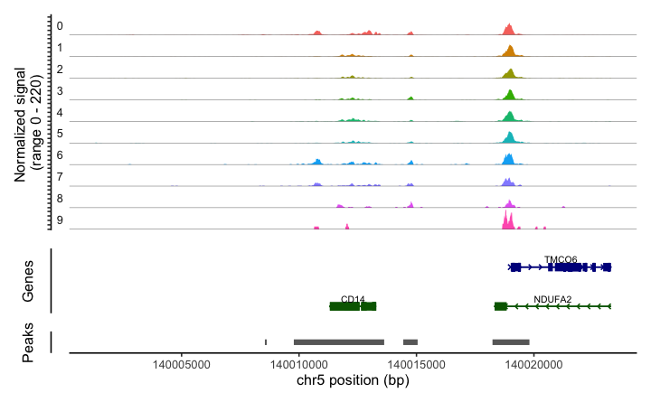

```r
CoveragePlot(seurat_obj,
             group.by="seurat_clusters",
             region = "CD14",
             extend.upstream = 10000, extend.downstream = 10000)
```

Clusters 6, 7, and 0 see to have accessible promoters around CD14. Perhaps these reflect myeloid lineages.

## Calculate “gene activity”

Another approach to infer expression is based on summing the ATAC counts for any region spanning the coding region for a gene +/- some window. Again, this is based on the association between expression and accessible chromatin. This is generically referred to as a “Gene activity matrix”

```r
gene.activities <- GeneActivity(seurat_obj)
```

```
Extracting gene coordinates
Extracting reads overlapping genomic regions
```

[output not shown]

```r
#Default is 2kb upstream and 0bp downstream
```

As this is essentially mimicking scRNA-seq data, we can create an RNA assay of this matrix and add it to our seurat object

```r
# add the gene activity matrix to the Seurat object as a new assay and normalize it
seurat_obj[['RNA']] <- CreateAssayObject(counts = gene.activities)
seurat_obj <- NormalizeData(
  object = seurat_obj,
  assay = 'RNA',
  normalization.method = 'LogNormalize',
  scale.factor = median(seurat_obj$nCount_RNA)
)
```

```r
seurat_obj
```

```
An object of class Seurat
107571 features across 7955 samples within 2 assays
Active assay: peaks (87561 features, 79009 variable features)
 2 layers present: counts, data
 1 other assay present: RNA
 2 dimensional reductions calculated: lsi, umap
```

We can now switch around between our available assays (peaks and RNA)

```r
DefaultAssay(seurat_obj) <- "RNA"
```

And now can use functions as if this were a scRNA-seq dataset

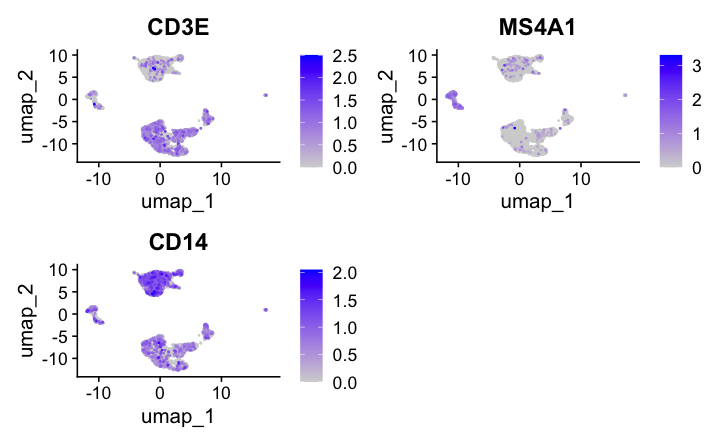

```r
FeaturePlot(seurat_obj, features=c("CD3E", "MS4A1", "CD14"), order=T)
```

Note that the signal of this is never as clean as actual RNA expression would be. This matrix can also be used as a strategy to integrate your scATAC-seq data with scRNA-seq data

# Differential accessibility

We are often interested in knowing which peaks are specific to a given cell type.

There are various approaches that can be taken for this, but a simple method is to just use a logistic regression to model accessibility in one cluster vs. the rest of the clusters (just as we did for scRNA-seq)

So cluster 1 was one of the putative T cell clusters. Let see which regions are specific to it.

```r
DefaultAssay(seurat_obj) <- "peaks" #go back to the ATAC assay
cluster1_markers <- FindMarkers(
  object = seurat_obj,
  ident.1 = 1,
  test.use = 'LR', #logistic regression
  latent.vars = 'nCount_peaks', #model effects of total counts so it doesn't confound results
  only.pos = T, #only positive peaks
  logfc.threshold = 2 #increase log fold change threshold just to speed up computation for workshop
)
```

[output not shown]

[output cut: 37 more lines]

[output not shown]

```r
head(cluster1_markers)
```

|  | p_val | avg_log2FC | pct.1 | pct.2 | p_val_adj |
| --- | --- | --- | --- | --- | --- |
| chr14-99721608-99741934 | 0.000000e+00 | 2.086286 | 0.797 | 0.215 | 0.000000e+00 |
| chr17-80084198-80086094 | 0.000000e+00 | 3.272220 | 0.495 | 0.064 | 0.000000e+00 |
| chr8-19353946-19355515 | 1.629939e-314 | 4.572705 | 0.344 | 0.017 | 1.427191e-309 |
| chr14-99695477-99720910 | 7.314873e-307 | 2.034469 | 0.714 | 0.187 | 6.404976e-302 |
| chr6-111408155-111410089 | 1.829605e-261 | 3.323957 | 0.373 | 0.041 | 1.602021e-256 |
| chr4-109086664-109091108 | 1.530457e-251 | 3.096609 | 0.397 | 0.050 | 1.340083e-246 |

Great! But we have no idea what these regions correspond to.

We can look at them with one of those ATAC trace plots

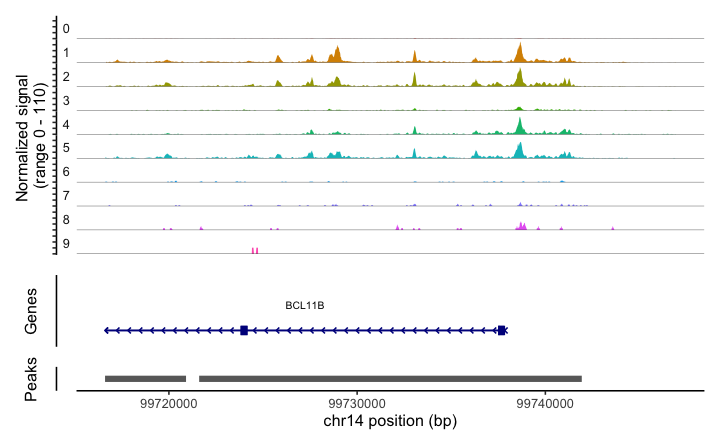

```r
CoveragePlot(seurat_obj,
             region = "chr14-99721608-99741934",
             group.by='seurat_clusters',
             extend.upstream = 5000, extend.downstream = 5000)
```

So it maps to a region in the first intron of the BCL11B gene.

We can use this `ClosestFeature` function to tell us the closest gene to each region in our list

```r
cluster1_markers$region <- rownames(cluster1_markers)
cluster1_features <- ClosestFeature(seurat_obj, regions = cluster1_markers$region)
```

And merge the tables together

```r
cluster1_markers <- left_join(cluster1_markers, cluster1_features,
                              by=c("region"="query_region"))
```

```r
head(cluster1_markers)
```

|  | p_val | avg_log2FC | pct.1 | pct.2 | p_val_adj | region | tx_id | gene_name | gene_id | gene_biotype | type | closest_region | distance |
| --- | --- | --- | --- | --- | --- | --- | --- | --- | --- | --- | --- | --- | --- |
| 1 | 0.000000e+00 | 2.086286 | 0.797 | 0.215 | 0.000000e+00 | chr14-99721608-99741934 | ENST00000443726 | BCL11B | ENSG00000127152 | protein_coding | cds | chr14-99737498-99737555 | 0 |
| 2 | 0.000000e+00 | 3.272220 | 0.495 | 0.064 | 0.000000e+00 | chr17-80084198-80086094 | ENST00000583593 | CCDC57 | ENSG00000176155 | protein_coding | cds | chr17-80085568-80085694 | 0 |
| 3 | 1.629939e-314 | 4.572705 | 0.344 | 0.017 | 1.427191e-309 | chr8-19353946-19355515 | ENST00000544602 | CSGALNACT1 | ENSG00000147408 | protein_coding | gap | chr8-19316154-19362711 | 0 |
| 4 | 7.314873e-307 | 2.034469 | 0.714 | 0.187 | 6.404976e-302 | chr14-99695477-99720910 | ENST00000357195 | BCL11B | ENSG00000127152 | protein_coding | cds | chr14-99697682-99697894 | 0 |
| 5 | 1.829605e-261 | 3.323957 | 0.373 | 0.041 | 1.602021e-256 | chr6-111408155-111410089 | ENST00000368851 | SLC16A10 | ENSG00000112394 | protein_coding | cds | chr6-111408956-111409298 | 0 |
| 6 | 1.530457e-251 | 3.096609 | 0.397 | 0.050 | 1.340083e-246 | chr4-109086664-109091108 | ENST00000515500 | LEF1 | ENSG00000138795 | protein_coding | cds | chr4-109087428-109087436 | 0 |

# Infer transcription factor activity

Transcription factors bind DNA motifs within accessible regions of the genome. We can predict relative transcription factor activity by quantifying the accessibility of TF motifs across cells.

We’ll use a wrapper function in Seurat/Signac that implements the population [chromVAR method](https://www.nature.com/articles/nmeth.4401)

```r
# Get a list of motif position frequency matrices from the JASPAR database
pfm <- getMatrixSet(
  x = JASPAR2022,
  opts = list(collection = "CORE", tax_group = 'vertebrates', all_versions = FALSE)
)

# Add motifs to the seurat object.
seurat_obj <- AddMotifs(
  object = seurat_obj,
  genome = BSgenome.Hsapiens.UCSC.hg19,
  pfm = pfm
)
```

```
Building motif matrix
Finding motif positions
Creating Motif object
Warning: Non-unique motif names supplied, making unique
```

The “motifs” section of our ChromatinAssay is now filled

```r
seurat_obj[['peaks']]@motifs
```

```
A Motif object containing 841 motifs in 87561 regions
```

```r
# seurat_obj[['peaks']]@motifs@data = a region-by-motif presence matrix
# seurat_obj[['peaks']]@motifs@pwm = position weight matrix for each motif
# seurat_obj[['peaks']]@motifs@motif.names = matches JASPAR ID to TF gene symbol--we'll use this later
# seurat_obj[['peaks']]@motifs@positions = a granges object for each motif providing locations for each motif
```

Now we can run chromVar which will compute the relative accessibility of motifs for each TF across all cells

```r
seurat_obj <- RunChromVAR(
  object = seurat_obj,
  genome = BSgenome.Hsapiens.UCSC.hg19
)
```

```
Computing GC bias per region
Selecting background regions
Computing deviations from background
Constructing chromVAR assay
```

ChromVAR will return yet another new assay in our seurat object

```r
seurat_obj
```

```
An object of class Seurat
108412 features across 7955 samples within 3 assays
Active assay: peaks (87561 features, 79009 variable features)
 2 layers present: counts, data
 2 other assays present: RNA, chromvar
 2 dimensional reductions calculated: lsi, umap
```

This `chromvar` assay contains a motif-by-cell matrix corresponding the relative activity level of the TF inferred by the algorithm

Right now the transcription factor IDs being used are the JASPAR IDs, which can be hard to navigate. Remember that the TF gene name is provided as metadata in the object

```r
tf_metadata
```

| jaspar_id | gene_id |
| --- | --- |
| MA0004.1 | Arnt |
| MA0006.1 | Ahr::Arnt |
| MA0019.1 | Ddit3::Cebpa |
| MA0029.1 | Mecom |
| MA0030.1 | FOXF2 |
| MA0031.1 | FOXD1 |
| MA0040.1 | Foxq1 |
| MA0051.1 | IRF2 |
| MA0059.1 | MAX::MYC |
| MA0066.1 | PPARG |

[output cut: 831 more lines]

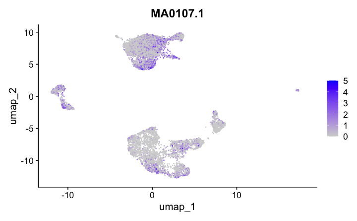

```r
DefaultAssay(seurat_obj) <- 'chromvar'
FeaturePlot(seurat_obj, features="MA0107.1", min.cutoff=0) #RELA
```

# Find over-represented motifs in a peak list

We can take those differentially accessible regions for cluster 1 and look for over-representation of TF motifs

```r
DefaultAssay(seurat_obj) <- "peaks" #the motifs data is attached to the ATAC assay (peaks)
enriched.motifs <- FindMotifs(
  object = seurat_obj,
  features = cluster1_markers$region
)
```

```
Selecting background regions to match input sequence characteristics
Matching GC.percent distribution
Testing motif enrichment in 455 regions
```

```r
head(enriched.motifs)
```

|  | motif | observed | background | percent.observed | percent.background | fold.enrichment | pvalue | motif.name | p.adjust |
| --- | --- | --- | --- | --- | --- | --- | --- | --- | --- |
| MA0523.1 | MA0523.1 | 194 | 6387 | 42.63736 | 15.9675 | 2.670259 | 4.250288e-42 | TCF7L2 | 3.574492e-39 |
| MA0768.2 | MA0768.2 | 171 | 5682 | 37.58242 | 14.2050 | 2.645718 | 1.569043e-35 | Lef1 | 6.597827e-33 |
| MA1991.1 | MA1991.1 | 165 | 5399 | 36.26374 | 13.4975 | 2.686700 | 7.369541e-35 | Hnf1A | 2.065928e-32 |
| MA0769.2 | MA0769.2 | 158 | 5108 | 34.72527 | 12.7700 | 2.719285 | 9.874610e-34 | TCF7 | 2.076137e-31 |
| MA0039.4 | MA0039.4 | 257 | 11856 | 56.48352 | 29.6400 | 1.905652 | 4.990859e-33 | KLF4 | 8.394624e-31 |
| MA0103.3 | MA0103.3 | 177 | 6344 | 38.90110 | 15.8600 | 2.452781 | 8.827061e-33 | ZEB1 | 1.237260e-30 |

TCF7 is a known TF associated with T cell development.

Note: Be careful interpreting results. Many TFs have similar motifs and can all be pulled up as hits in this type of analysis. You can look at the motif with the following function. You can also try to determine whether the TF is actually expressed in the cell (eg. with the gene activity matrix or from reference scRNA-seq)

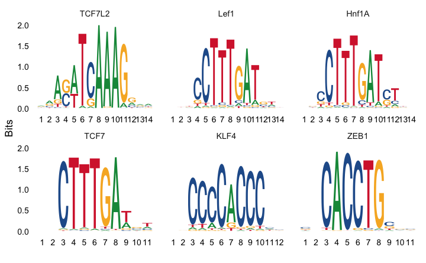

```r
MotifPlot(
  object = seurat_obj,
  motifs = head(enriched.motifs$motif)
)
```

Note Left1 and Hnf1a similarity

# Optional: Integrate with scRNA-seq

## Load and process RNA

```r
rna_counts <- Read10X("../data/filtered_gene_bc_matrices/hg19")
rna_obj <- CreateSeuratObject(counts = rna_counts,
                              min.cells=3,
                              min.features=10)
rna_obj <- NormalizeData(rna_obj) %>%
  FindVariableFeatures() %>%
  ScaleData() %>%
  RunPCA(verbose=F) %>%
  RunUMAP(dims=1:25) %>%
  FindNeighbors(dims=1:25) %>%
  FindClusters(resolution=0.2)
```

```
Warning: The following arguments are not used: nselectCalculating gene variances

Found more than one class "dist" in cache; using the first, from namespace 'spam'
Also defined by 'BiocGenerics'
Found more than one class "dist" in cache; using the first, from namespace 'spam'
Also defined by 'BiocGenerics'
Using method 'umap'
```

```
Modularity Optimizer version 1.3.0 by Ludo Waltman and Nees Jan van Eck

Number of nodes: 2700
Number of edges: 132924

Running Louvain algorithm...
```

[output not shown]

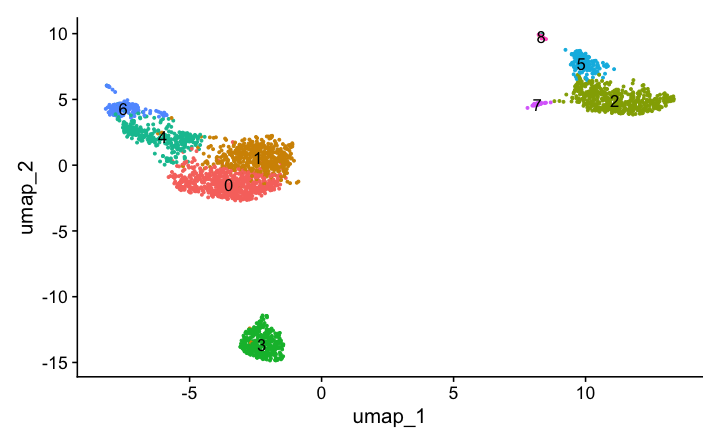

```r
DimPlot(rna_obj, label=T) + NoLegend()
```

## Integrate

Here, we’ll use Seurat’s CCA integration method to integrate the scRNA-seq data with the “Gene Activities” matrix from the scATAC data.

You can do this to actually merge the objects together, but there’s usually no reason to do this. Often, we’re interested in something more practical, like project cell type labels from the RNA-seq onto the ATAC data, which is usually harder to annoate

```r
predicted.labels <- TransferData(
  anchorset = transfer.anchors,
  refdata = rna_obj$seurat_clusters,
  weight.reduction = seurat_obj[['lsi']],
  dims = 2:30 # remember that component 1 = technical--correlated with total peak counts
)
```

```
Finding integration vectors
Finding integration vector weights
Predicting cell labels
```

[figure not shown]

Interesting that we seem to be resolving some T cell populations in the ATAC data that aren’t particularly clear in the RNA data. Note that the RNA data only has the one cluster 4 population that maps to two different clusters in the ATAC data (clusters 2 and 5). [Note: depending on our installation environments, our embeddings and clustering may differ slightly, so do not be concerned if our cluster numbers are different]

Let’s see if we can find regulatory regions associated with these clusters

We could do differential peak accessibility to look for specific regions, or for a rough prediction of differential expression, we can to typical DGE on that Gene Activity matrix

```r
DefaultAssay(seurat_obj) <- "RNA"
cluster2_markers <- FindMarkers(
  seurat_obj,
  ident.1=2,
  only.pos=T,
  logfc.threshold = 1)
```

[output not shown]

```r
cluster2_markers
```

|  | p_val | avg_log2FC | pct.1 | pct.2 | p_val_adj |
| --- | --- | --- | --- | --- | --- |
| KRT74 | 0.000000e+00 | 1.907394 | 0.460 | 0.039 | 0.000000e+00 |
| IFNG | 0.000000e+00 | 1.837174 | 0.490 | 0.042 | 0.000000e+00 |
| JAKMIP1 | 0.000000e+00 | 1.692468 | 0.878 | 0.173 | 0.000000e+00 |
| CXXC11 | 1.118674e-296 | 1.839875 | 0.584 | 0.082 | 2.238466e-292 |
| CST7 | 5.332526e-289 | 1.812597 | 0.777 | 0.163 | 1.067038e-284 |
| S1PR5 | 5.287768e-252 | 1.597980 | 0.606 | 0.104 | 1.058082e-247 |
| CADM1 | 2.024109e-250 | 1.235165 | 0.797 | 0.192 | 4.050243e-246 |
| LGR6 | 2.934593e-250 | 1.627594 | 0.766 | 0.185 | 5.872120e-246 |
| CD8A | 4.221189e-249 | 1.981693 | 0.829 | 0.250 | 8.446599e-245 |
| NFATC2 | 8.211428e-245 | 1.686664 | 0.984 | 0.473 | 1.643107e-240 |

[output cut: 100 more lines]

This would be differential accessibility of the ATAC signal

```r
cluster5_features <- ClosestFeature(seurat_obj, regions = cluster5_markers$region)
```